# Clustering methods

# 4 Hierarchical K-Means Clustering

K-means, as we know, is very sensitive to the initial choices made regarding the number of clusters we want to find and to the initial positioning of the centroids. Therefore, one possible improvement that can be made is to integrate a hierarchical clustering approach in the initial stage of the k-means algorithm, to better initialize the centroids when applying k-means. This is what the hierarchical k-means clustering algorithm does, allowing to obtain more robust clusters with respect to the classical k-means.

Let’s apply the algorithm:

```r
res.hk <-hkmeans(Prostate_no_outliers_sc,3)
```

Print the results:

```r
res.hk
```

```
## Hierarchical K-means clustering with 3 clusters of sizes 17, 13, 16
##
## Cluster means:
##          age          wt        sbp        dbp         hg         sz         sg
## 1  0.1882887  0.50642363  0.7090406  0.9561726  0.6905556 -0.2369977 -0.1998273
## 2 -0.4897788 -0.61417705 -0.1342213 -0.5285940 -0.3450701  0.7178314  1.0838337
## 3  0.1978886 -0.03905626 -0.6443008 -0.5864508 -0.4533458 -0.3314280 -0.6682984
##           ap
## 1 -0.3813673
## 2  1.1483270
## 3 -0.5278129
##
## Clustering vector:
##  [1] 1 2 1 1 2 2 1 2 2 3 3 1 3 2 3 3 1 3 3 1 3 2 3 3 1 1 1 1 2 3 2 2 3 3 3 1 3 1
## [39] 1 2 2 1 1 1 3 2
##
## Within cluster sum of squares by cluster:
## [1]  75.08889 105.01228  56.64030
##  (between_SS / total_SS =  34.2 %)
##
## Available components:
##
##  [1] "cluster"      "centers"      "totss"        "withinss"     "tot.withinss"
##  [6] "betweenss"    "size"         "iter"         "ifault"       "data"
## [11] "hclust"
```

Visualize the dendrogram:

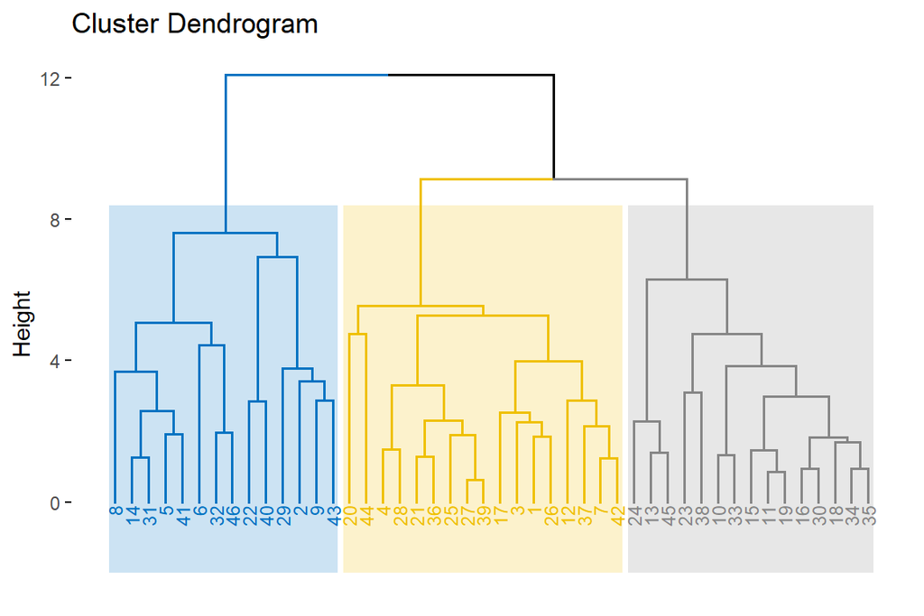

```r
fviz_dend(res.hk, cex = 0.6, palette = "jco",
          rect = TRUE, rect_border = "jco", rect_fill = TRUE)
```

Visualize the final clusters:

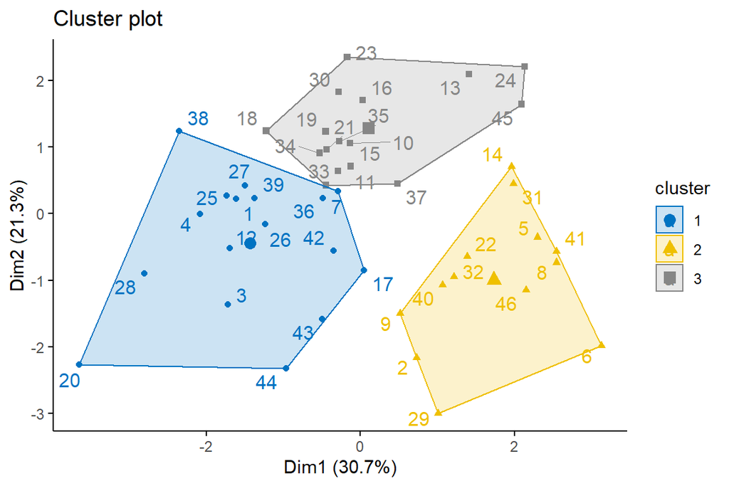

```r
fviz_cluster(res.hk, palette = "jco", repel = TRUE,
             ggtheme = theme_classic())
```

Let’s visualize one beside the other the results of k-means and the hierarchical k-means we just performed, to visualize the eventual differences:

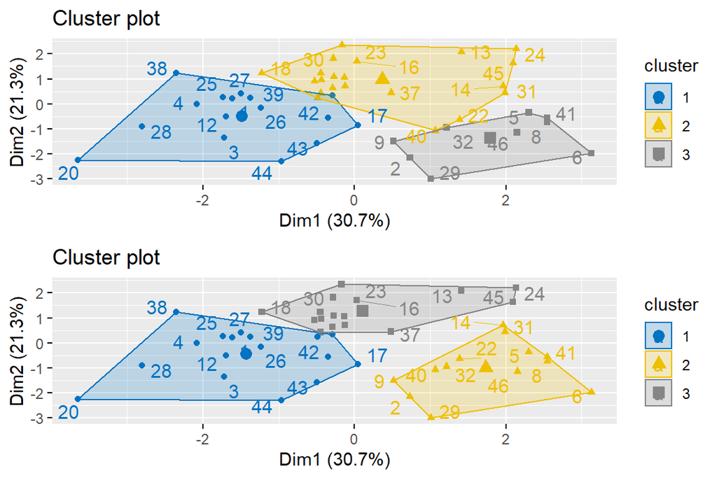

```r
g1 <- fviz_cluster(k3,  data = Prostate_no_outliers_sc, palette = "jco", repel = TRUE)
g2 <- fviz_cluster(res.hk, palette = "jco", repel = TRUE)
grid.arrange(g1, g2)
```

The plot shows that the introduction of the hierachical clustering initialization in the k-means improves the separation between the clusters already found with classical k-means. Indeed the 3 groups are more separated in the 2nd case.

# 5 Model-based clustering

In model-based clustering, the data is considered as coming from a mixture of distributions.

In our case, we consider a Gaussian mixture model, where each component k in the model can be considered as a cluster and is modeled by a normal distribution

Model-based clustering doesn’t require to do a standardization, but we’ll use the standardized data to be able to compare the results of the different algorithms.

We’ll use the R package *mclust* which estimates the model’s parameters by EM algorithm initialized by hierarchical model-based agglomerative clustering. The optimal model is then selected according to the BIC criteria:

The function we’ll use describes the obtained model with a character string composed by 3 characters indicating the characteristics of the model at which the optimal BIC occurs: * the first character refers to volume * the second to shape * the third to orientation

In details: character E stands for “equal”, V for “variable” and I for “coordinate axes”.

Let’s now load the library of interest:

```r
library(mclust)
```

We can now perform the fitting and print a summary of the obtained model:

```r
mc <- Mclust(Prostate_no_outliers_sc)
summary(mc) # Print a summary
```

```
## ----------------------------------------------------
## Gaussian finite mixture model fitted by EM algorithm
## ----------------------------------------------------
##
## Mclust VVI (diagonal, varying volume and shape) model with 2 components:
##
##  log-likelihood  n df       BIC       ICL
##       -378.9979 46 33 -884.3409 -884.4017
##
## Clustering table:
##  1  2
## 28 18
```

To better understand the results of the algorithm, we can analyze one by one the outputs of the *Mclust* function:

Name of the optimal model:

```r
mc$modelName
```

```
## [1] "VVI"
```

Number of clusters in the optimal model:

```r
mc$G
```

```
## [1] 2
```

Probability to belong to a given cluster:

```r
mc$z  %>%
    as.data.frame(.) %>%
  sample_n(., 10, replace=FALSE) %>%
  kbl(caption = "Probability to belong to a given cluster (sample of 10)") %>%
  kable_classic(full_width = F, html_font = "Cambria")
```

Probability to belong to a given cluster (sample of 10)

| V1 | V2 |
| --- | --- |
| 0.9985860 | 0.0014140 |
| 0.0000000 | 1.0000000 |
| 0.9985823 | 0.0014177 |
| 1.0000000 | 0.0000000 |
| 0.9999569 | 0.0000431 |
| 0.9996022 | 0.0003978 |
| 0.9999941 | 0.0000059 |
| 0.0000000 | 1.0000000 |
| 0.9999960 | 0.0000040 |
| 0.9999919 | 0.0000081 |

We know that model-based clustering is a soft-clustering technique: therefore we have for each sample a probability to belong to each one of the clusters. The above table, shows that for this sample of data, the assignment of points to clusters is pretty strong, since we have high probabilities for each observation to belong to a single specific cluster.

We can also visualize the cluster allocation of each observation:

```r
head(mc$classification,10) # first 10 observations
```

```
##  [1] 1 2 1 1 2 2 1 2 2 1
```

We can use the function *plot.Mclust* in the *mclust* package to plot the results of the algorithm. Some graphs can be plotted by using the *factoextra* package, which uses *ggplot2* providing a better plotting style.

We can graph the *BIC values* used for choosing the number of clusters:

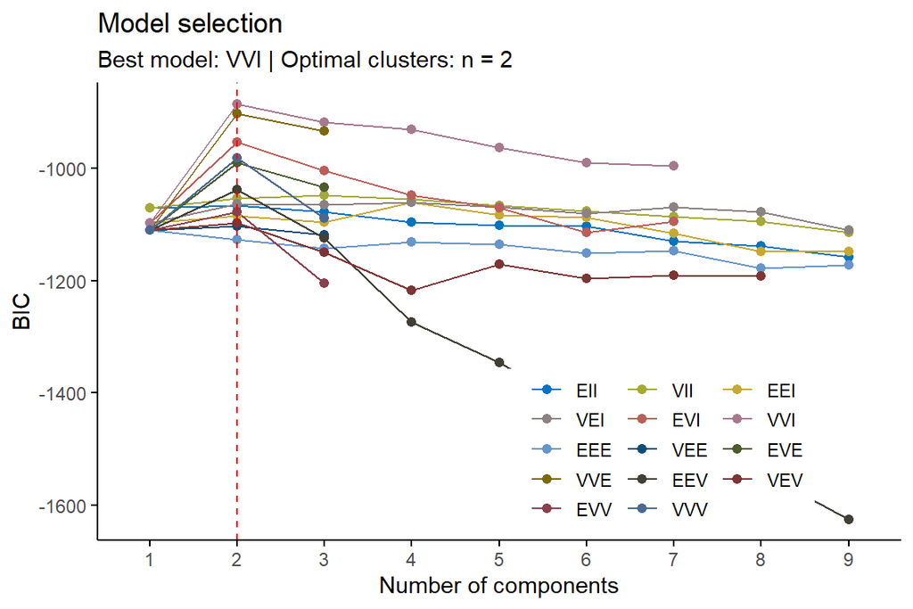

```r
library(factoextra)
fviz_mclust(mc, "BIC", palette = "jco")
```

We can modify the above graph to show only the final optimal model we are interested in using the function *fviz_mclust_bic*:

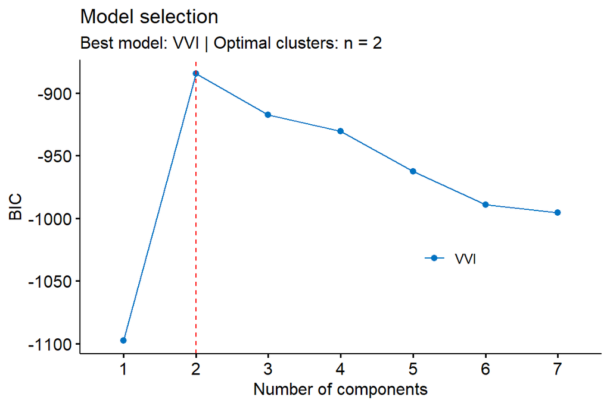

```r
library(factoextra)
fviz_mclust_bic(mc, model.names=mc$modelName, palette = "jco")
```

From *mclust*, we can obtain the top BIC ranking:

```r
summary(mc$BIC)
```

```
## Best BIC values:
##              VVI,2      VVE,2      VVI,3
## BIC      -884.3409 -902.43344 -917.26093
## BIC diff    0.0000  -18.09254  -32.92002
```

By specifying the ‘classification’ paramerer we chan visualize a plot showing the clustering.

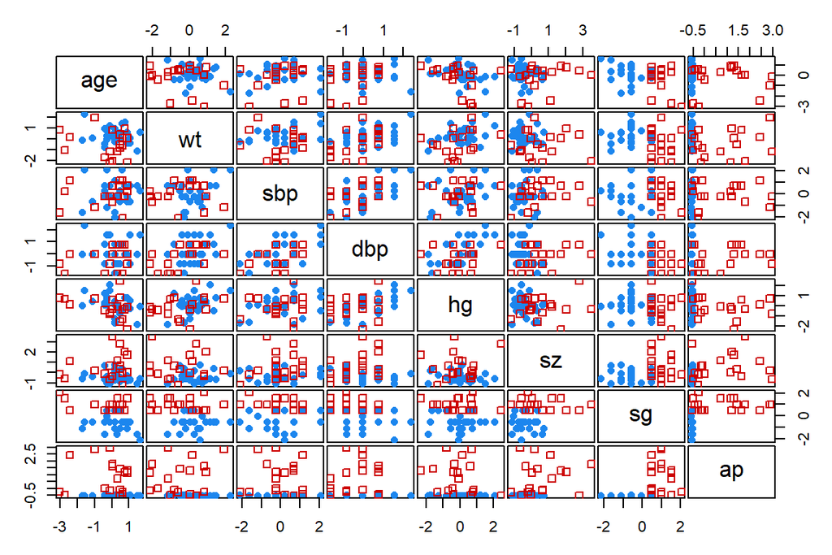

```r
plot.Mclust(mc, what="classification", addEllipses = FALSE)
```

Ellipses corresponding to covariances of mixture components are also drawn if *addEllipses = TRUE*.:

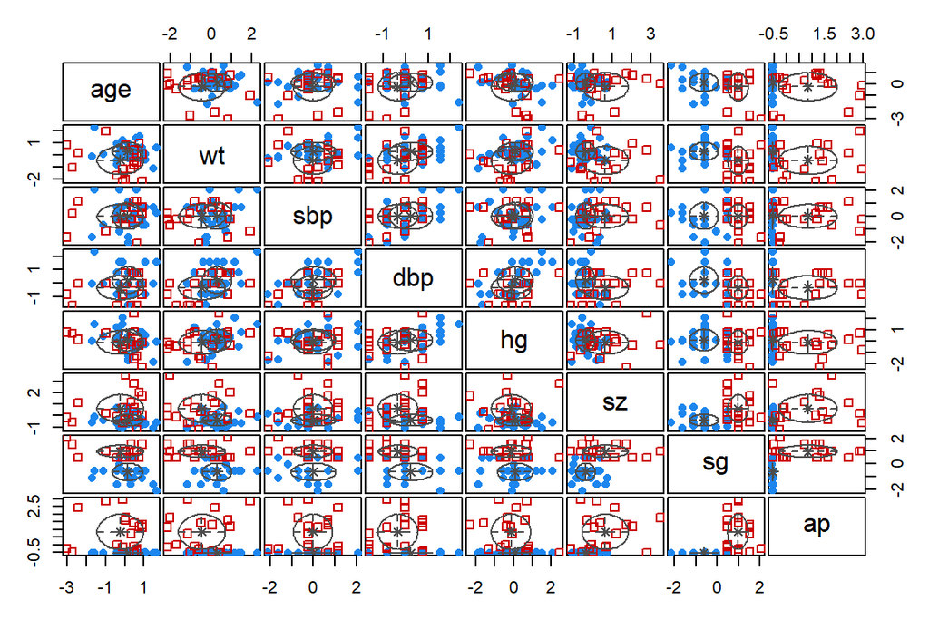

```r
plot.Mclust(mc, what="classification", addEllipses = TRUE)
```

The above plots are not very clear due to the high number of variables used for performing the clustering: indeed they show the found clusters in the graph with each group of 2 variables. The above plots show for instance that variables ‘sg’ and ‘ap’ are very discriminatory for the separation of points into the 2 groups.

We may prefer to show the clustering result in the first factorial plane (obtained through PCA). To do that we can use the *factoextra* package wich performs a PCA to show the results in the first 2 PCs:

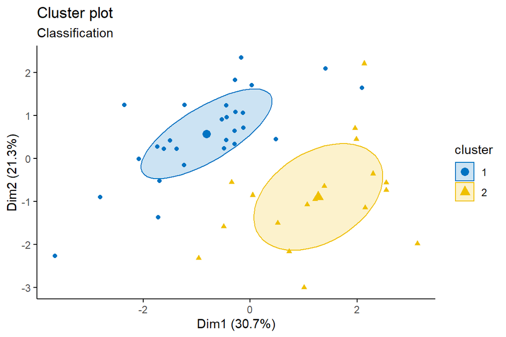

```r
fviz_mclust(mc, "classification", geom = "point",
            pointsize = 1.5, palette = "jco")
```

In the 1st factorial plane the 2 clusters are pretty well separated by the diagonal of the 1st quadrant.

We can now plot the classification uncertainty:

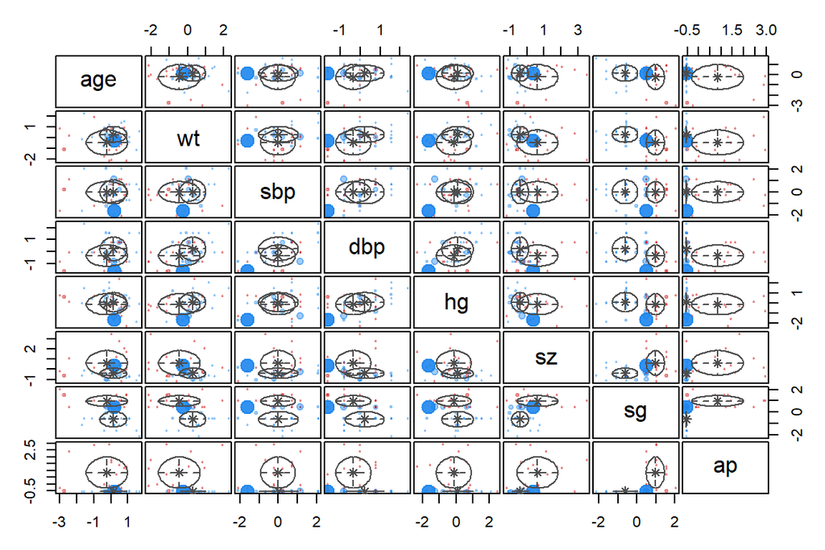

```r
plot.Mclust(mc, what="uncertainty")
```

In this plot, *larger symbols indicate the more uncertain observations*. The package *factoextra* provides a better visualization for classification uncertainty on the first factorial plane (first 2 PCs):

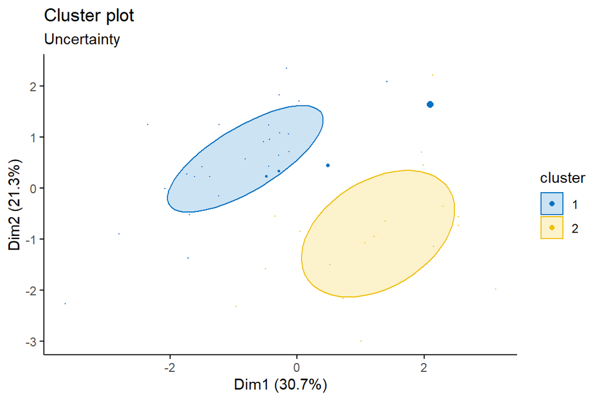

```r
fviz_mclust(mc, "uncertainty", palette = "jco")
```

The plot shows that there are some points outside the 2 represented densities, with one of them (around position (2,2)) showed with high size, indicating a pretty strong uncertainty in its cluster association.

We can also visualize a plot of the estimated density:

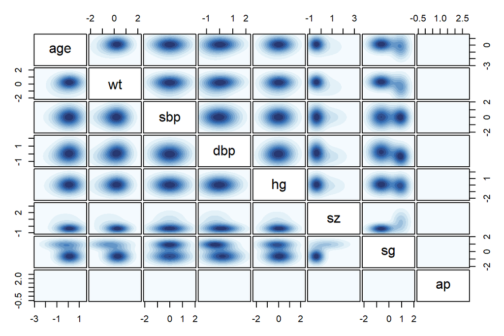

```r
plot.Mclust(mc, what="density", type = "image", col="steelblue", grid = 200)
```

We can also show 3D graphs of the estimated densities:

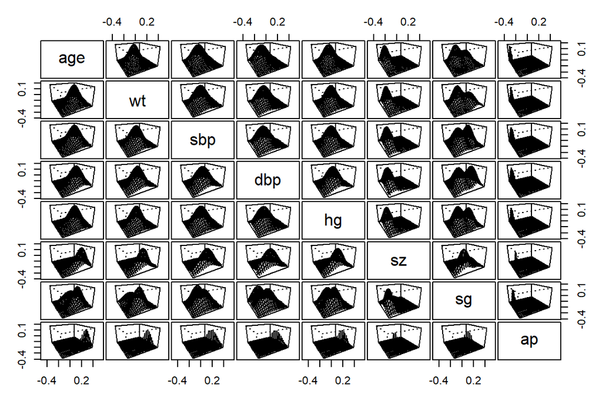

```r
plot.Mclust(mc, what="density", type="persp")
```

To better show the results we discussed above, we may plot the data using only two variables of interest: we can select ‘sg’ as one of them (since, as said before, it discriminates very well the 2 groups) and ‘dbp’:

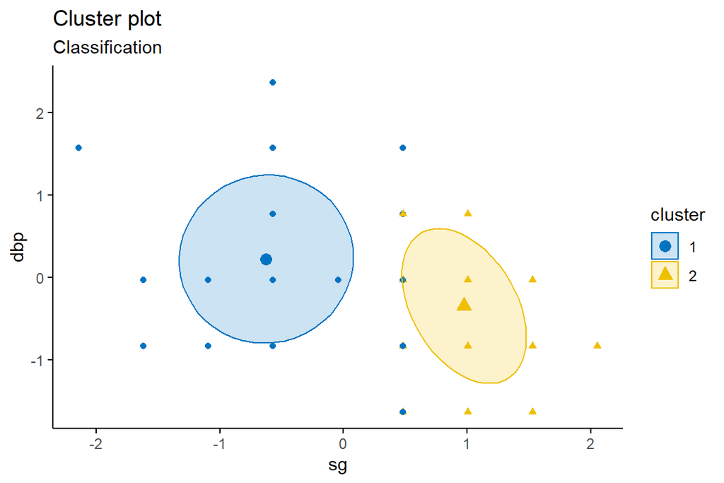

```r
# Classification: plot showing the clustering
fviz_mclust(mc, "classification", geom = "point",
            pointsize = 1.5, palette = "jco",
            choose.vars = c("sg", "dbp"))
```

As expected, these 2 variables are pretty good in discrimating the 2 groups.

It is possible to use also another dimensionality reduction method for visualizing the clustering structure obtained from a finite mixture of Gaussian densities with the function *MclustDR*.

The estimated directions which span the reduced subspace are defined as a set of *linear combinations of the original features, ordered by importance as quantified by the associated eigenvalues*:

```r
drmc <- MclustDR(mc, lambda = 1)
summary(drmc)
```

```
## -----------------------------------------------------------------
## Dimension reduction for model-based clustering and classification
## -----------------------------------------------------------------
##
## Mixture model type: Mclust (VVI, 2)
##
## Clusters  n
##        1 28
##        2 18
##
## Estimated basis vectors:
##          Dir1
## age  0.070479
## wt  -0.196547
## sbp  0.038618
## dbp -0.165069
## hg   0.204623
## sz   0.244341
## sg   0.754339
## ap   0.507014
##
##                 Dir1
## Eigenvalues   1.2384
## Cum. %      100.0000
```

In our case, the above method reduced the data to only 1 direction, which captures most of the clustering structure found with the model-based algorithm.

The projected plot on this new direction would be:

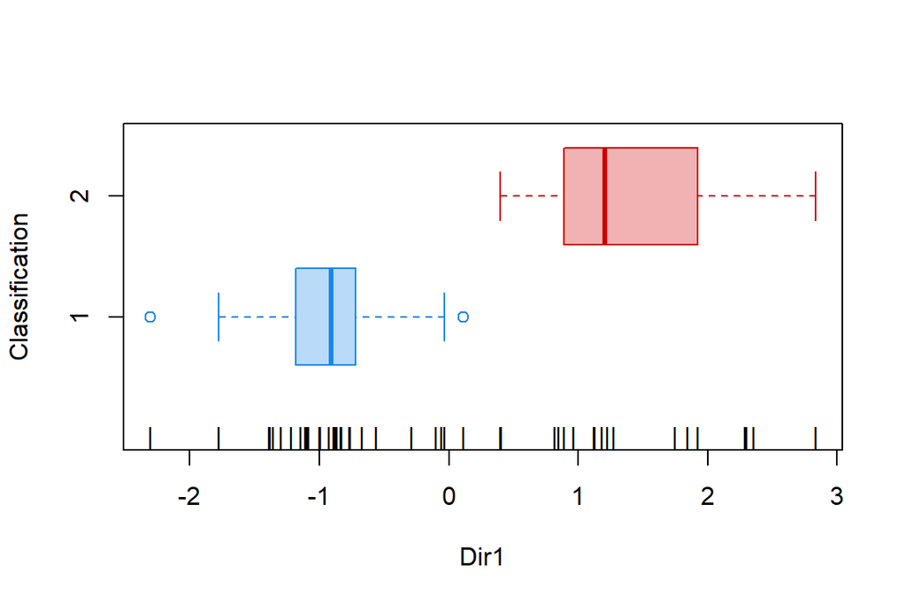

```r
plot(drmc, what = "contour")
```

The plot allows to visualize, with a sort of box-plot, also the uncertainty in assigning the observations into the 2 clusters. The box-plots show also the values in the new direction (Dir1) of the observations in each cluster, and we can see that the data are very well classified into 2 groups.

We can also visualize the density:

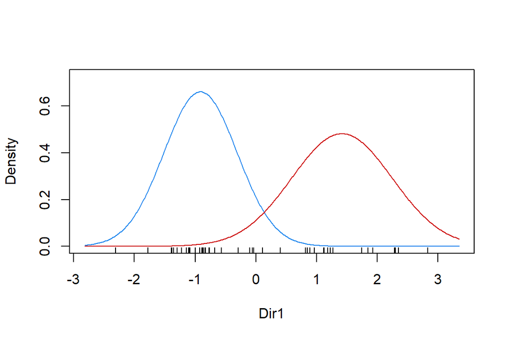

```r
plot(drmc, what = "density")
```

Save image of all objects created in the session:

```r
save.image(file="Clustering.RData")
```